# Lab 04 - Data Visualization

```r
#install.packages(c("data.table","leaflet"))
library(data.table)
library(leaflet)
library(tidyverse)
```

# Learning Goals

- Read in and prepare the meteorological dataset
- Create several graphs with different `geoms()` in `ggplot2`
- Create a facet graph
- Conduct some customizations of the graphs
- Create a more detailed map using `leaflet()`

# Lab Description

We will again work with the meteorological data presented in lecture.

**The objective of the lab is to examine the association between weekly average dew point temperature and wind speed in four regions of the US and by elevation.**

# Steps

### 1. Read in the data

First download and then read in with data.table:fread()

```r
fn <- "https://raw.githubusercontent.com/JSC370/jsc370-2023/main/labs/lab03/met_all.gz"
if (!file.exists("met_all.gz"))
  download.file(fn, destfile = "met_all.gz")
met <- data.table::fread("met_all.gz")
```

### 2. Prepare the data

- Remove temperatures less than -17C
- Make sure there are no missing data in the key variables coded as 9999, 999, etc
- Generate a date variable using the functions `as.Date()` (hint: You will need the following to create a date `paste(year, month, day, sep = "-")`).
- Using the `data.table::week` function, keep the observations of the first week of the month.
- Compute the mean by station of the variables `temp`, `rh`, `wind.sp`, `vis.dist`, `dew.point`, `lat`,`lon`, and `elev`.
- Create a categorical variable for elevation (break point at 252 m)
- Create a region variable for NW, SW, NE, SE based on lon = -98.00 and lat = 39.71 degrees

```r
summary(met$temp)
```

```
##    Min. 1st Qu.  Median    Mean 3rd Qu.    Max.    NA's
##  -40.00   20.00   23.90   23.82   28.00   56.00   57902
```

```r
summary(met$elev)
```

```
##    Min. 1st Qu.  Median    Mean 3rd Qu.    Max.
##   -13.0    94.0   237.0   407.3   391.0  9999.0
```

```r
summary(met$dew.point)
```

```
##    Min. 1st Qu.  Median    Mean 3rd Qu.    Max.    NA's
##  -37.20   14.00   18.50   17.22   22.00   36.00   63934
```

```r
# Remove temperatures less than -17/code 9999 elev as NA
met <- met %>% filter(temp > -17) %>% mutate(elev = ifelse(elev == 9999, NA, elev))
# create the week variable
met[, week := week(as.Date(paste(year, month, day, sep = "-")))]
# select the first week
met_first_week <- met[week == min(week, na.rm = TRUE)]
# group and compute means
met_avg <- met_first_week[, .(temp = mean(temp, na.rm=TRUE),
                              rh = mean(rh, na.rm=TRUE),
                              wind.sp = mean(wind.sp, na.rm=TRUE),
                              vis.dist = mean(vis.dist, na.rm=TRUE),
                              dew.point = mean(dew.point, na.rm=TRUE),
                              lat = mean(lat, na.rm=TRUE),
                              lon = mean(lon, na.rm=TRUE),
                              elev = mean(elev, na.rm=TRUE)
                              ), by="USAFID"]
# categorize elevation
met_avg[,elev_cat := ifelse(elev >252, "high", "low")]

# categorize regions
met_avg[, region:= case_when(
  lon >= -98.00 & lat >= 39.71 ~ "NE",
  lon >= -98.00 & lat < 39.71 ~ "SE",
  lon < -98.00 & lat >= 39.71 ~ "NW",
  TRUE ~ "SW"
)]
```

### 3. Use `geom_violin` to examine the wind speed and dew point temperature by region

You saw how to use `geom_boxplot` in class. Try using `geom_violin` instead (take a look at the help). (hint: You will need to set the `x` aesthetic to 1)

- Use facets
- Make sure to deal with `NA` category
- Describe what you observe in the graph

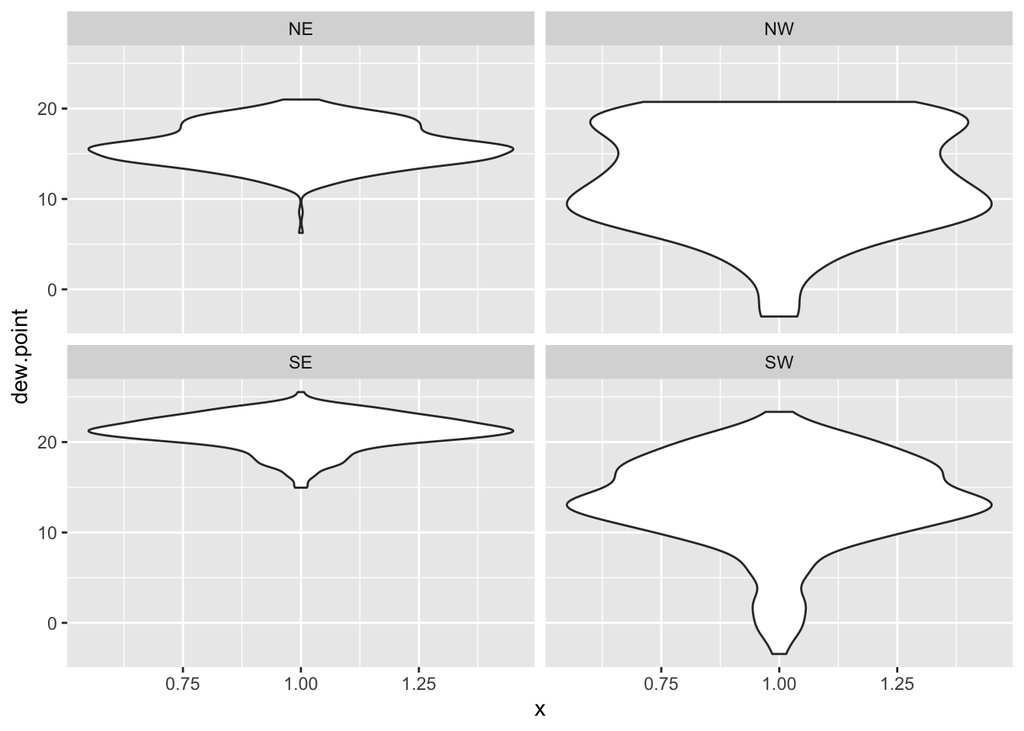

```r
met_avg %>% filter(!is.na(region)) %>%
  ggplot(aes(y = dew.point, x=1)) +
  geom_violin() + facet_wrap(~region)
```

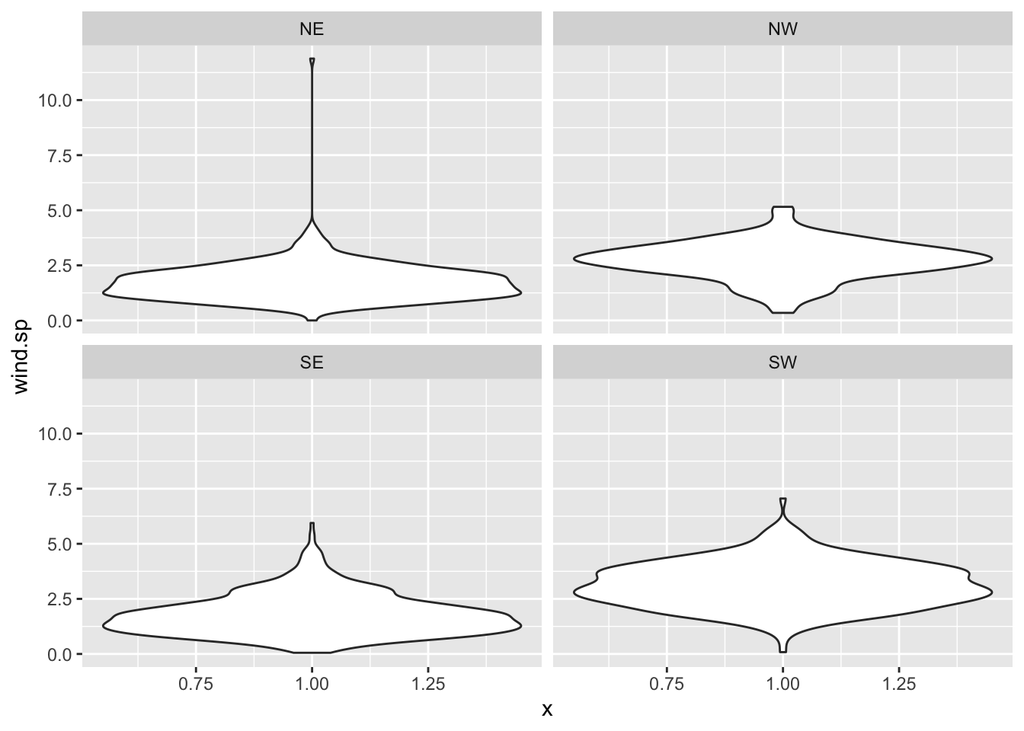

```r
met_avg %>% filter(!is.na(region)) %>%
  ggplot(aes(y = wind.sp, x=1)) +
  geom_violin() + facet_wrap(~region)
```

### 4. Use `geom_jitter` with `stat_smooth` to examine the association between dew point temperature and wind speed by region

- Color points by region
- Make sure to deal with `NA` category
- Fit a linear regression line by region
- **Describe** what you observe in the graph

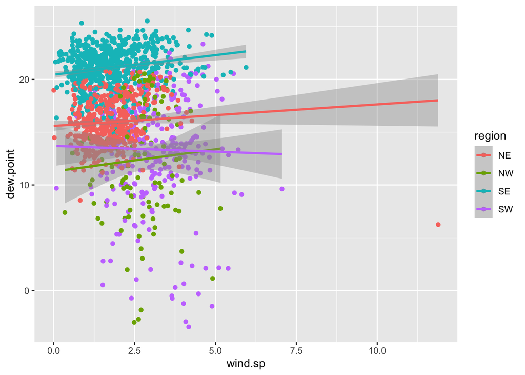

```r
met_avg %>% filter(!is.na(region)) %>%
  ggplot(aes(y = dew.point, x=wind.sp, color = region)) +
  geom_jitter() + geom_smooth(method = lm)
```

We observe that in each region, the dew point doesn’t change a lot as wind speed changes.

### 5. Use `geom_bar` to create barplots of the weather stations by elevation category coloured by region

- Bars by elevation category using `position = "dodge"`
- Change colors from the default. Color by region using `scale_fill_brewer` see [this](http://rstudio-pubs-static.s3.amazonaws.com/5312_98fc1aba2d5740dd849a5ab797cc2c8d.html)
- Create nice labels on axes and add a title
- Try a different theme
- Describe what you observe in the graph
- Make sure to deal with `NA`

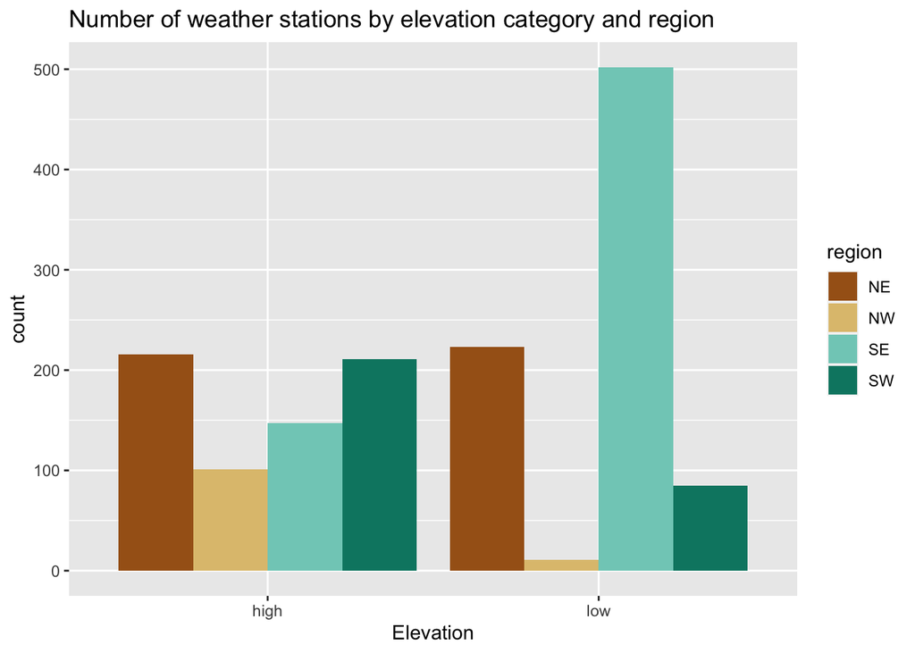

```r
met_avg %>% filter(!is.na(region), !is.na(elev_cat)) %>%
  ggplot(aes(x = elev_cat, fill = region)) +
  geom_bar(position = "dodge") +
  scale_fill_brewer(palette = "BrBG") +
  labs(title = "Number of weather stations by elevation category and region",
       x = "Elevation")
```

### 6. Use `stat_summary` to examine mean dew point and wind speed by region with standard deviation error bars

- Make sure to remove `NA`
- Use fun.data=“mean_sdl” in `stat_summary`
- Add another layer of `stats_summary` but change the geom to `"errorbar"` (see the help).
- Describe the graph and what you observe

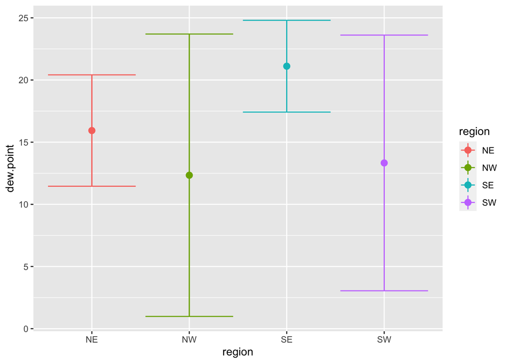

```r
met_avg %>% filter(!is.na(region), !is.na(dew.point)) %>%
  ggplot(aes(y = dew.point, x=region, color = region)) +
  stat_summary(fun.data = "mean_sdl", geom = "errorbar") +
  stat_summary(fun.data = "mean_sdl")
```

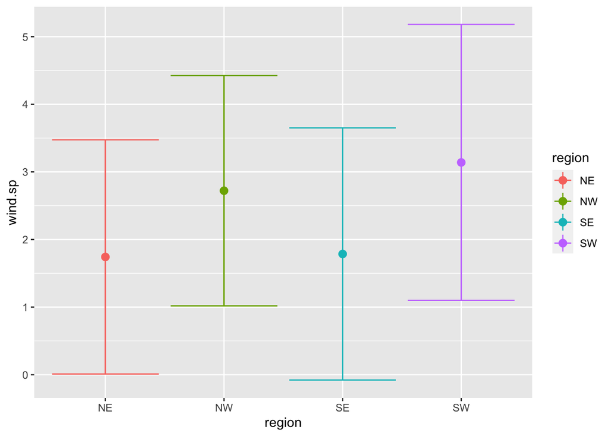

```r
met_avg %>% filter(!is.na(region), !is.na(wind.sp)) %>%
  ggplot(aes(y = wind.sp, x=region, color = region)) +
  stat_summary(fun.data = "mean_sdl", geom = "errorbar") +
  stat_summary(fun.data = "mean_sdl")
```

- Dew point temperature is highest at SE for around 22, with the less variation (around 4). The Dew point at NE is second-highest at around 17 with second less variation (around 5). THe Dew points at NW and SW are similar arount a level of 12 with large variation (around 10)
- Wind speed is at similar level (1.8) for NE and SE with similar variation of 1.8, and Wind speed is at a little bit higher level for NW and SW at 2.8, 3.2 respectively.

### 7. Make a map showing the spatial trend in relative humidity (`rh`) in the US

- Make sure to remove `NA`
- Use `leaflet()`
- Make a colour palette with custom colours
- Use `addMarkers` to include the top 10 places in relative h (hint: this will be useful `rank(-rh) <= 10`)
- Add a legend
- Describe trend in RH across the US

```r
met_avg2 <- met_avg[!is.na(rh)]
top10 <- met_avg2[rank(-rh) <= 10]
```

```r
rh_pal <- colorNumeric(c('lightgrey', 'lightblue', 'blue', 'darkblue'),
                       domain = met_avg2$rh)

leaflet(met_avg2) %>%
  addProviderTiles("OpenStreetMap") %>%
  addCircles(lat=~lat, lng=~lon, color = ~rh_pal(rh)) %>%
  addMarkers(lat=~lat, lng=~lon, data = top10) %>%
  addLegend("bottomleft", pal = rh_pal, values = met_avg2$rh, title = "title", opacity = 1)
```

[interactive chart not shown]

### 8. Use a ggplot extension

- Pick and extension (except cowplot) from [here](https://exts.ggplot2.tidyverse.org/gallery/) and make a plot of your choice using the `met` data (or `met_avg`)
- Might want to try examples that come with the extension first (e.g. `ggtech`, `gganimate`, `ggforce`)

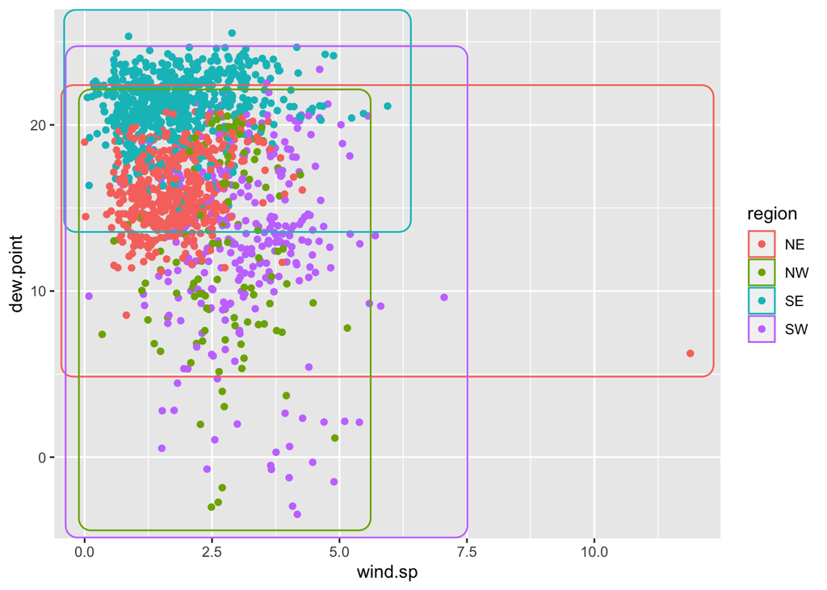

```r
# install.packages("ggforce")
library(ggforce)
met_avg %>% filter(!is.na(region)) %>%
  ggplot(aes(y = dew.point, x=wind.sp, color = region)) +
  geom_jitter() +
  geom_mark_rect()
```